## Stabil, Brudi!

### First, understand the problem ….

Wir implementieren (partiell!) eine sehr allgemeine Methode für Variablenselektion für verschiedene Modellklassen. Die Methode wird beschrieben in Meinshausen und Bühlmann’s *Stability Selection*[^1] [(pdf)](http://stat.ethz.ch/~nicolai/stability.pdf).

1. Lesen und verstehen Sie Sections 1, 2 und 5 des oben verlinkten Papers. Ignorieren Sie dabei die Abschnitte über “Gaussian graphical modelling” und “randomized Lasso”.
2. Überprüpfen Sie ihr Verständnis. Betrachten Sie dazu den linken und den mittleren Plot in Figure 1 auf Seite 5 oben. Was genau repräsentiert die horizontale Achse ($\lambda$)? Was repräsentieren jeweils die vertikalen Achsen ($\beta$ bzw. $\Pi$)? Warum fangen in beiden Plots alle Pfade in (1.0, 0.0) an?
3. Fassen Sie die Grundidee des Stability Selection Algorithmus in eigenen Worten zusammen. Was sind grob die einzelnen Schritte des Algorithmus um die “stability paths” zu berechnen?  
   Erstellen Sie eine erste eigene Skizze einer Implementation des Algorithmus in Pseudo-Code, in dem in der Vorlesung besprochenen Top-Down-Stil.

*Hinweis*: Falls nötig finden Sie eine einigermaßen übersichtliche Beschreibung der Grundidee von Lasso-Regression anhand derer in dem Paper die *stability selection*-Methode veranschaulicht wird z.B. in Kapitel 3.4.2 aus T. Hastie und R. Tibshirani’s *Elements of Statistical Learning* [(pdf)](http://statweb.stanford.edu/~tibs/ElemStatLearn/).

### … then, write the code:

Benutzen Sie als Ausgangsbasis den Code in `get-stability-paths.R`.

Die `refit`-Funktion können Sie hier zunächst mal als “black box” betrachten. Beachten Sie bitte dass Sie eventuell noch die Pakete `{leaps}` und `{ElemStatLearn}` installieren müssen.

## Stabil, Brudi: Resampling

Schreiben Sie die fehlenden Funktionen

```r
sample_without_replacement <- function(nrows, strata = NULL, fraction = 0.5) {
  # ??
}
get_selected <- function(new_model) {
  # ??
}
make_paths <- function(selected) {
  # ??
}
```

`get_selected` sollte für ein gegebenes Modell eine Matrix mit (max. Subsetgröße+1)$\times$(Anz. Kovariablen) zurückgeben, `make_paths` sollte für eine Liste solcher Matrizen eine Matrix die die *stability paths* enthält zurückgeben. Die erste Zeile der Matrizen sollte (Selektionshäufigkeiten für) ein Modell ohne Kovariablen repräsentieren.

*Hinweis / Spoiler:* Die für `get_selected` benötigten Informationen über ein von `regsubsets` erzeugtes Modellobjekt können Sie mit `summary` in die Konsole drucken lassen.  
Benutzen sie `str` in Kombination mit `summary` um zu verstehen wo & wie diese Informationen abgespeichert sind um diese dann per Code auslesen zu können.

Überprüfen Sie Ihren Code mit folgendem Test:

```r
# ---- test-get-stability-paths ----

library(MASS)
# Dieses package ist nur noch in archivierten Versionen verfügbar, leider:
# remotes::install_version("ElemStatLearn")
data(prostate, package = "ElemStatLearn")
data <- prostate

max_formula <- lpsa ~ (. - train)
model <- leaps::regsubsets(max_formula,
                    data = data, nbest = 1, nvmax = 8,
                    really.big = TRUE
)

set.seed(20141020)
stability_paths <- get_stability_paths(model, data, reps = 1000)
stability_paths
```

```
##   lcavol lweight   age  lbph   svi   lcp gleason pgg45
## 0  0.000   0.000 0.000 0.000 0.000 0.000   0.000 0.000
## 1  0.994   0.000 0.000 0.000 0.005 0.000   0.000 0.001
## 2  0.998   0.559 0.003 0.088 0.320 0.004   0.002 0.026
## 3  1.000   0.743 0.075 0.245 0.777 0.027   0.022 0.111
## 4  0.999   0.805 0.432 0.408 0.848 0.135   0.148 0.225
## 5  1.000   0.882 0.673 0.570 0.922 0.296   0.260 0.397
## 6  1.000   0.925 0.836 0.707 0.965 0.567   0.406 0.594
## 7  1.000   0.979 0.937 0.884 0.989 0.847   0.577 0.787
## 8  1.000   1.000 1.000 1.000 1.000 1.000   1.000 1.000
```

### Visualisierung

Schreiben Sie eine Funktion `plot_stability_paths`, die in etwa so etwas wie die untenstehende Grafik erzeugt.

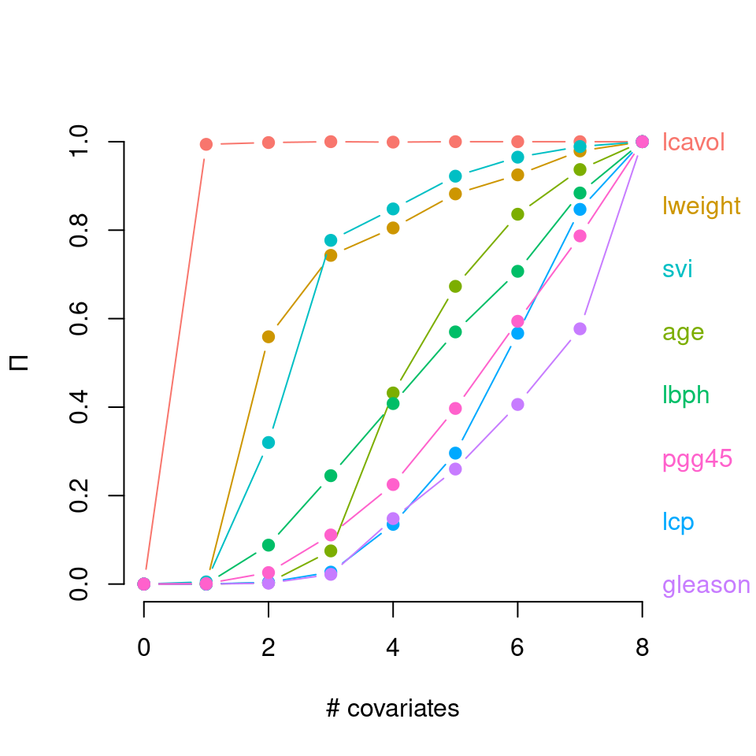

```r
plot_stability_paths(stability_paths)
```

[^1]: Meinshausen, N., & Bühlmann, P. (2010). Stability selection. Journal of the Royal Statistical Society: Series B (Statistical Methodology), 72(4), 417-473.